# DANL 310 Lecture 09

February 24, 2022

## Work with models; Draw maps

## R packages

```r
library(tidyverse)
library(socviz)
library(gapminder)
library(skimr)
library(ggrepel)
library(ggthemes)
library(broom)
theme_set(theme_minimal())
```

## Work with models

- Let us consider the linear regression of `lifeExp` on `gdpPercap`, `pop`, and `continent`.

```r
out <- lm(formula = lifeExp ~ log(gdpPercap) + pop + continent,
          data = gapminder)

summary(out)
```

```
##
## Call:
## lm(formula = lifeExp ~ log(gdpPercap) + pop + continent, data = gapminder)
##
## Residuals:
##      Min       1Q   Median       3Q      Max
## -26.7090  -3.4832   0.4396   4.4062  18.6914
##
## Coefficients:
##                    Estimate Std. Error t value Pr(>|t|)
## (Intercept)       1.476e+00  1.352e+00   1.091    0.275
## log(gdpPercap)    6.524e+00  1.824e-01  35.778  < 2e-16 ***
## pop               9.990e-09  1.650e-09   6.056 1.72e-09 ***
## continentAmericas 6.729e+00  5.507e-01  12.218  < 2e-16 ***
## continentAsia     5.157e+00  4.880e-01  10.567  < 2e-16 ***
## continentEurope   9.290e+00  5.997e-01  15.491  < 2e-16 ***
## continentOceania  8.965e+00  1.521e+00   5.896 4.49e-09 ***
## ---
## Signif. codes:  0 '***' 0.001 '**' 0.01 '*' 0.05 '.' 0.1 ' ' 1
##
## Residual standard error: 6.965 on 1697 degrees of freedom
## Multiple R-squared:  0.7102, Adjusted R-squared:  0.7092
## F-statistic: 693.3 on 6 and 1697 DF,  p-value: < 2.2e-16
```

```r
str(out)
```

```
## List of 13
##  $ coefficients : Named num [1:7] 1.48 6.52 9.99e-09 6.73 5.16 ...
##   ..- attr(*, "names")= chr [1:7] "(Intercept)" "log(gdpPercap)" "pop" "continentAmericas" ...
##  $ residuals    : Named num [1:1704] -21.4 -20.2 -18.8 -16.6 -13.8 ...
##   ..- attr(*, "names")= chr [1:1704] "1" "2" "3" "4" ...
##  $ effects      : Named num [1:1704] -2455.1 430.5 58.4 26.9 -24 ...
##   ..- attr(*, "names")= chr [1:1704] "(Intercept)" "log(gdpPercap)" "pop" "continentAmericas" ...
##  $ rank         : int 7
##  $ fitted.values: Named num [1:1704] 50.2 50.5 50.8 50.6 49.9 ...
##   ..- attr(*, "names")= chr [1:1704] "1" "2" "3" "4" ...
##  $ assign       : int [1:7] 0 1 2 3 3 3 3
##  $ qr           :List of 5
##   ..$ qr   : num [1:1704, 1:7] -41.2795 0.0242 0.0242 0.0242 0.0242 ...
##   .. ..- attr(*, "dimnames")=List of 2
##   .. .. ..$ : chr [1:1704] "1" "2" "3" "4" ...
##   .. .. ..$ : chr [1:7] "(Intercept)" "log(gdpPercap)" "pop" "continentAmericas" ...
##   .. ..- attr(*, "assign")= int [1:7] 0 1 2 3 3 3 3
##   .. ..- attr(*, "contrasts")=List of 1
##   .. .. ..$ continent: chr "contr.treatment"
##   ..$ qraux: num [1:7] 1.02 1.03 1.01 1.01 1.04 ...
##   ..$ pivot: int [1:7] 1 2 3 4 5 6 7
##   ..$ tol  : num 1e-07
##   ..$ rank : int 7
##   ..- attr(*, "class")= chr "qr"
##  $ df.residual  : int 1697
##  $ contrasts    :List of 1
##   ..$ continent: chr "contr.treatment"
##  $ xlevels      :List of 1
##   ..$ continent: chr [1:5] "Africa" "Americas" "Asia" "Europe" ...
##  $ call         : language lm(formula = lifeExp ~ log(gdpPercap) + pop + continent, data = gapminder)
##  $ terms        :Classes 'terms', 'formula'  language lifeExp ~ log(gdpPercap) + pop + continent
##   .. ..- attr(*, "variables")= language list(lifeExp, log(gdpPercap), pop, continent)
##   .. ..- attr(*, "factors")= int [1:4, 1:3] 0 1 0 0 0 0 1 0 0 0 ...
##   .. .. ..- attr(*, "dimnames")=List of 2
##   .. .. .. ..$ : chr [1:4] "lifeExp" "log(gdpPercap)" "pop" "continent"
##   .. .. .. ..$ : chr [1:3] "log(gdpPercap)" "pop" "continent"
##   .. ..- attr(*, "term.labels")= chr [1:3] "log(gdpPercap)" "pop" "continent"
##   .. ..- attr(*, "order")= int [1:3] 1 1 1
##   .. ..- attr(*, "intercept")= int 1
##   .. ..- attr(*, "response")= int 1
```

[output cut: 9 more lines]

```
##   ..- attr(*, "terms")=Classes 'terms', 'formula'  language lifeExp ~ log(gdpPercap) + pop + continent
##   .. .. ..- attr(*, "variables")= language list(lifeExp, log(gdpPercap), pop, continent)
##   .. .. ..- attr(*, "factors")= int [1:4, 1:3] 0 1 0 0 0 0 1 0 0 0 ...
##   .. .. .. ..- attr(*, "dimnames")=List of 2
##   .. .. .. .. ..$ : chr [1:4] "lifeExp" "log(gdpPercap)" "pop" "continent"
##   .. .. .. .. ..$ : chr [1:3] "log(gdpPercap)" "pop" "continent"
##   .. .. ..- attr(*, "term.labels")= chr [1:3] "log(gdpPercap)" "pop" "continent"
##   .. .. ..- attr(*, "order")= int [1:3] 1 1 1
##   .. .. ..- attr(*, "intercept")= int 1
##   .. .. ..- attr(*, "response")= int 1
##   .. .. ..- attr(*, ".Environment")=<environment: R_GlobalEnv>
##   .. .. ..- attr(*, "predvars")= language list(lifeExp, log(gdpPercap), pop, continent)
##   .. .. ..- attr(*, "dataClasses")= Named chr [1:4] "numeric" "numeric" "numeric" "factor"
##   .. .. .. ..- attr(*, "names")= chr [1:4] "lifeExp" "log(gdpPercap)" "pop" "continent"
##  - attr(*, "class")= chr "lm"
```

- Try `out$coefficients`, `out$residuals`, and `out$fitted.values`.

## Tidy model objects with `broom`

- The `broom` package to help us do a lot of things with our model output.
- `broom` can tidily extract three kinds of information.
  - We can see *component-level* information about aspects of the model itself, such as **coefficients** and **t-statistics**.
  - We can obtain *observation-level* information about the model’s connection to the underlying data, such as **fitted values** and **residuals**.
  - We can get *model-level* information that summarizes the fit as a whole, such as **F-statistic**, **model deviance**, or **r-squared**.

```r
library(broom)
```

## Get component-level statistics with `tidy()`

- The `tidy()` function takes a model object and returns a data frame of component-level information.

```r
out_comp <- tidy(out)
out_comp %>% round_df()
```

```
## # A tibble: 7 × 5
##   term              estimate std.error statistic p.value
##   <chr>                <dbl>     <dbl>     <dbl>   <dbl>
## 1 (Intercept)           1.48      1.35      1.09    0.28
## 2 log(gdpPercap)        6.52      0.18     35.8     0
## 3 pop                   0         0         6.06    0
## 4 continentAmericas     6.73      0.55     12.2     0
## 5 continentAsia         5.16      0.49     10.6     0
## 6 continentEurope       9.29      0.6      15.5     0
## 7 continentOceania      8.96      1.52      5.9     0
```

## Get component-level statistics with `tidy()`

- We can work with `tidy()` to make plots in a familiar way, and much more easily.

```r
p <- ggplot(out_comp, mapping = aes(x = term,
                                    y = estimate))

p + geom_point() + coord_flip()
```

## Get component-level statistics with `tidy()`

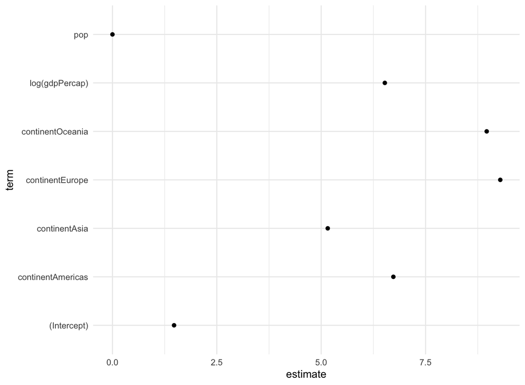

## Get component-level statistics with `tidy()`

- We can tell `tidy()` to calculate confidence intervals for the estimates, using R’s `conf.int = TRUE` option.

```r
out_conf <- tidy(out, conf.int = TRUE)
out_conf %>% round_df()
```

```
## # A tibble: 7 × 7
##   term              estimate std.error statistic p.value conf.low conf.high
##   <chr>                <dbl>     <dbl>     <dbl>   <dbl>    <dbl>     <dbl>
## 1 (Intercept)           1.48      1.35      1.09    0.28    -1.18      4.13
## 2 log(gdpPercap)        6.52      0.18     35.8     0        6.17      6.88
## 3 pop                   0         0         6.06    0        0         0
## 4 continentAmericas     6.73      0.55     12.2     0        5.65      7.81
## 5 continentAsia         5.16      0.49     10.6     0        4.2       6.11
## 6 continentEurope       9.29      0.6      15.5     0        8.11     10.5
## 7 continentOceania      8.96      1.52      5.9     0        5.98     12.0
```

## Get component-level statistics with `tidy()`

- We can tell `tidy()` to calculate confidence intervals for the estimates, using R’s `conf.int = TRUE` option.

```r
out_conf <- subset(out_conf, term != "(Intercept)")
out_conf$nicelabs <- prefix_strip(out_conf$term, "continent")
```

- The `socviz::prefix_strip()` strips a series of characters from the beginning of a character vector.

## Get component-level statistics with `tidy()`

- We can use `geom_pointrange()` to make a figure that displays some information about our confidence in the variable estimates

```r
p <- ggplot(out_conf, mapping = aes(x = reorder(nicelabs, estimate),
                                    y = estimate, ymin = conf.low, ymax = conf.high))
p + geom_pointrange() + coord_flip() + labs(x="", y="OLS Estimate")
```

## Get component-level statistics with `tidy()`

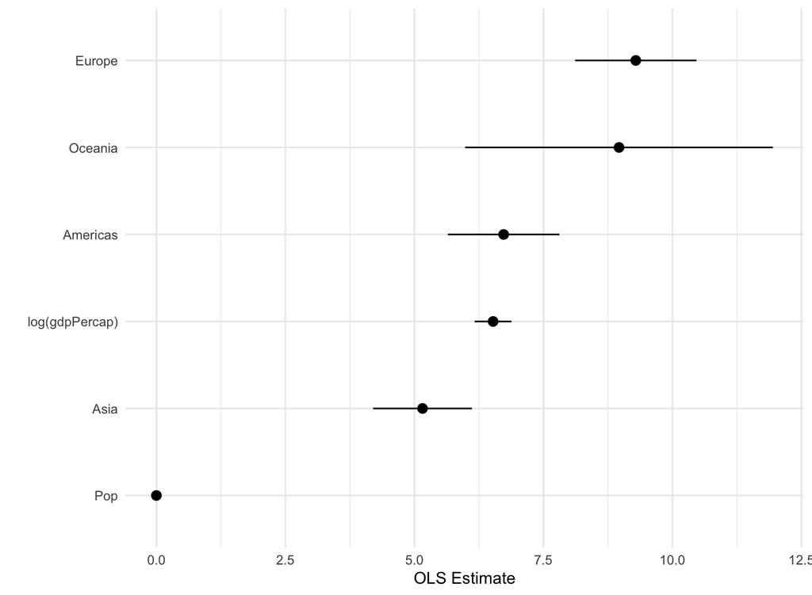

## Get observation-level statistics with `augment()`

- The values returned by `augment()` are all statistics calculated at the level of the original observations.
- Working from a call to `augment()` will return a data frame with all the original observations used in the estimation of the model, together with columns like the following:
  - `.fitted` — The fitted values of the model.
  - `.se.fit` — The standard errors of the fitted values.
  - `.resid` — The residuals; `.std.resid` — The standardized residuals.
  - `.hat` — The diagonal of the hat matrix.
  - `.sigma` — An estimate of residual standard deviation when the corresponding observation is dropped from the model.
  - `.cooksd` — Cook’s distance, a common regression diagnostic on how the observation is influential in the estimation;

## Get observation-level statistics with `augment()`

```r
out_aug <- augment(out)
head(out_aug)
```

```
## # A tibble: 6 × 9
##   lifeExp `log(gdpPercap)`      pop continent .fitted    .hat .sigma .cooksd
##     <dbl>            <dbl>    <int> <fct>       <dbl>   <dbl>  <dbl>   <dbl>
## 1    28.8             6.66  8425333 Asia         50.2 0.00427   6.95 0.00578
## 2    30.3             6.71  9240934 Asia         50.5 0.00416   6.95 0.00503
## 3    32.0             6.75 10267083 Asia         50.8 0.00408   6.95 0.00426
## 4    34.0             6.73 11537966 Asia         50.6 0.00410   6.96 0.00337
## 5    36.1             6.61 13079460 Asia         49.9 0.00433   6.96 0.00244
## 6    38.4             6.67 14880372 Asia         50.3 0.00419   6.96 0.00175
## # … with 1 more variable: .std.resid <dbl>
```

```r
head(out_aug) %>% round_df()
```

```
## # A tibble: 6 × 9
##   lifeExp `log(gdpPercap)`      pop continent .fitted  .hat .sigma .cooksd
##     <dbl>            <dbl>    <dbl> <fct>       <dbl> <dbl>  <dbl>   <dbl>
## 1    28.8             6.66  8425333 Asia         50.2     0   6.95    0.01
## 2    30.3             6.71  9240934 Asia         50.5     0   6.95    0.01
## 3    32               6.75 10267083 Asia         50.8     0   6.95    0
## 4    34.0             6.73 11537966 Asia         50.6     0   6.96    0
## 5    36.1             6.61 13079460 Asia         49.9     0   6.96    0
## 6    38.4             6.67 14880372 Asia         50.3     0   6.96    0
## # … with 1 more variable: .std.resid <dbl>
```

## Get observation-level statistics with `augment()`

- The new columns created by `augment()` can be used to create some standard regression plots.
  - We can draw the residual plot (the residuals versus the fitted values).

```r
p <- ggplot(data = out_aug,
            mapping = aes(x = .fitted, y = lifeExp - .fitted))
p + geom_point()
```

## Get observation-level statistics with `augment()`

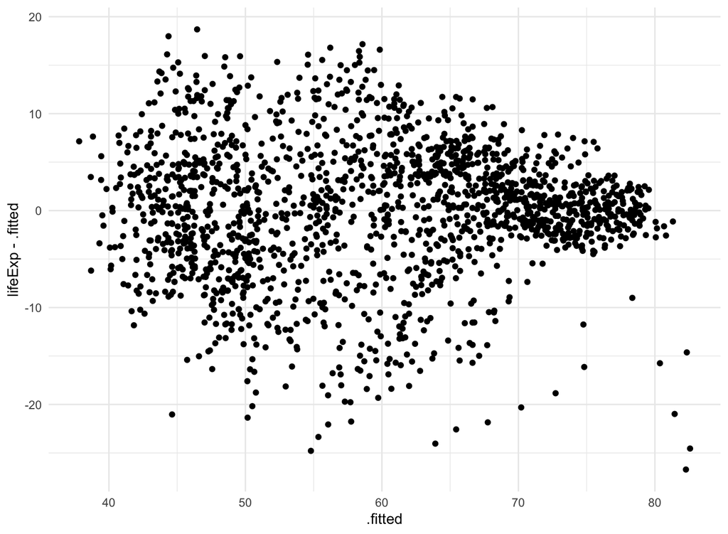

## Get model-level statistics with `glance()`

- `glance()` returns the information typically presented at the bottom of a model’s `summary()` output.

```r
glance(out) %>% round_df()
```

```
## # A tibble: 1 × 12
##   r.squared adj.r.squared sigma statistic p.value    df logLik    AIC    BIC
##       <dbl>         <dbl> <dbl>     <dbl>   <dbl> <dbl>  <dbl>  <dbl>  <dbl>
## 1      0.71          0.71  6.97      693.       0     6 -5722. 11460. 11503.
## # … with 3 more variables: deviance <dbl>, df.residual <dbl>, nobs <dbl>
```

## Grouped analysis and list columns

- Consider the linear regression model for the relationship between life expectancy and GDP by continent, for each year in the data.

```r
eu77 <- gapminder %>% filter(continent == "Europe", year == 1977)
fit <- lm(lifeExp ~ log(gdpPercap), data = eu77)
summary(fit)
```

```
##
## Call:
## lm(formula = lifeExp ~ log(gdpPercap), data = eu77)
##
## Residuals:
##     Min      1Q  Median      3Q     Max
## -7.4956 -1.0306  0.0935  1.1755  3.7125
##
## Coefficients:
##                Estimate Std. Error t value Pr(>|t|)
## (Intercept)      29.489      7.161   4.118 0.000306 ***
## log(gdpPercap)    4.488      0.756   5.936 2.17e-06 ***
## ---
## Signif. codes:  0 '***' 0.001 '**' 0.01 '*' 0.05 '.' 0.1 ' ' 1
##
## Residual standard error: 2.114 on 28 degrees of freedom
## Multiple R-squared:  0.5572, Adjusted R-squared:  0.5414
## F-statistic: 35.24 on 1 and 28 DF,  p-value: 2.173e-06
```

## Grouped analysis and list columns

- With `dplyr` and `broom` we can do the grouped analysis for every continent-year slice of the data in a compact and tidy way.

```r
out_le <- gapminder %>%
    group_by(continent, year) %>%
    nest()
out_le
```

```
## # A tibble: 60 × 3
## # Groups:   continent, year [60]
##    continent  year data
##    <fct>     <int> <list>
##  1 Asia       1952 <tibble [33 × 4]>
##  2 Asia       1957 <tibble [33 × 4]>
##  3 Asia       1962 <tibble [33 × 4]>
##  4 Asia       1967 <tibble [33 × 4]>
##  5 Asia       1972 <tibble [33 × 4]>
##  6 Asia       1977 <tibble [33 × 4]>
##  7 Asia       1982 <tibble [33 × 4]>
##  8 Asia       1987 <tibble [33 × 4]>
##  9 Asia       1992 <tibble [33 × 4]>
## 10 Asia       1997 <tibble [33 × 4]>
## # … with 50 more rows
```

- `nest()` creates a list-column of data frames.
  - The list column, `data`, contains a small table of data corresponding to each continent-year group.

## Grouped analysis and list columns

- We can look at specific group, for example, “Europe 1977”, if we like, by filtering the data and then unnesting the list column.

```r
out_le %>% filter(continent == "Europe" & year == 1977) %>%
  unnest()
```

```
## # A tibble: 30 × 6
## # Groups:   continent, year [1]
##    continent  year country                lifeExp      pop gdpPercap
##    <fct>     <int> <fct>                    <dbl>    <int>     <dbl>
##  1 Europe     1977 Albania                   68.9  2509048     3533.
##  2 Europe     1977 Austria                   72.2  7568430    19749.
##  3 Europe     1977 Belgium                   72.8  9821800    19118.
##  4 Europe     1977 Bosnia and Herzegovina    69.9  4086000     3528.
##  5 Europe     1977 Bulgaria                  70.8  8797022     7612.
##  6 Europe     1977 Croatia                   70.6  4318673    11305.
##  7 Europe     1977 Czech Republic            70.7 10161915    14800.
##  8 Europe     1977 Denmark                   74.7  5088419    20423.
##  9 Europe     1977 Finland                   72.5  4738902    15605.
## 10 Europe     1977 France                    73.8 53165019    18293.
## # … with 20 more rows
```

## Grouped analysis and list columns

- List columns are useful because we can act on them in a compact and tidy way.

```r
fit_ols <- function(df) {
    lm(lifeExp ~ log(gdpPercap), data = df)
}

out_le <- gapminder %>%
    group_by(continent, year) %>%
    nest() %>%
    mutate(model = map(data, fit_ols))

out_le
```

```
## # A tibble: 60 × 4
## # Groups:   continent, year [60]
##    continent  year data              model
##    <fct>     <int> <list>            <list>
##  1 Asia       1952 <tibble [33 × 4]> <lm>
##  2 Asia       1957 <tibble [33 × 4]> <lm>
##  3 Asia       1962 <tibble [33 × 4]> <lm>
##  4 Asia       1967 <tibble [33 × 4]> <lm>
##  5 Asia       1972 <tibble [33 × 4]> <lm>
##  6 Asia       1977 <tibble [33 × 4]> <lm>
##  7 Asia       1982 <tibble [33 × 4]> <lm>
##  8 Asia       1987 <tibble [33 × 4]> <lm>
##  9 Asia       1992 <tibble [33 × 4]> <lm>
## 10 Asia       1997 <tibble [33 × 4]> <lm>
## # … with 50 more rows
```

- `map()` function applies a function to each element of a vector.

## Grouped analysis and list columns

```r
fit_ols <- function(df) {
    lm(lifeExp ~ log(gdpPercap), data = df)
}

out_tidy <- gapminder %>%
    group_by(continent, year) %>%
    nest() %>%
    mutate(model = map(data, fit_ols),
           tidied = map(model, tidy)) %>%
    unnest(tidied) %>%
    filter(term != "(Intercept)" &
           continent != "Oceania")
```

## Grouped analysis and list columns

- We now have tidy regression output with an estimate of the association between log GDP per capita and life expectancy *for each year*, *within continents*.

```r
p <- ggplot(data = out_tidy,
            mapping = aes(x = year, y = estimate,
                          ymin = estimate - 2*std.error,
                          ymax = estimate + 2*std.error,
                          group = continent, color = continent))

p + geom_pointrange(position = position_dodge(width = 1)) +
    scale_x_continuous(breaks = unique(gapminder$year)) +
    theme(legend.position = "top") +
    labs(x = "Year", y = "Estimate", color = "Continent")
```

## Grouped analysis and list columns

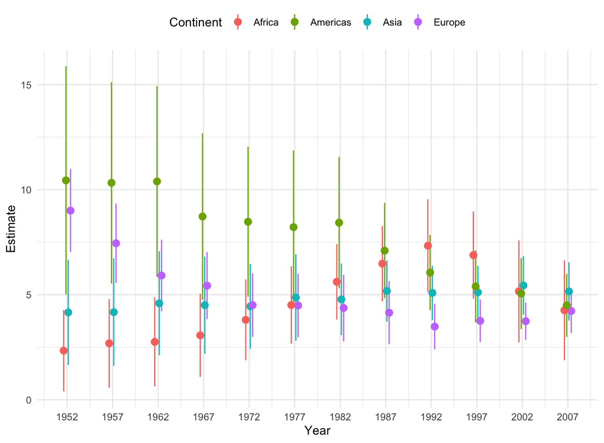

## Map U.S. state-level data

- The `socviz::election` dataset has various measures of the vote and vote shares by state.

```r
election %>% select(state, total_vote,
                    r_points, pct_trump, party, census) %>%
    sample_n(5)
```

```
## # A tibble: 5 × 6
##   state          total_vote r_points pct_trump party      census
##   <chr>               <dbl>    <dbl>     <dbl> <chr>      <chr>
## 1 Tennessee         2508027    26         60.7 Republican South
## 2 Alabama           2123372    27.7       62.1 Republican South
## 3 Arkansas          1130635    26.9       60.6 Republican South
## 4 North Carolina    4741564     3.66      49.8 Republican South
## 5 Arizona           2604657     3.5       48.1 Republican West
```

- We don’t have to represent spatial data spatially.

## Map U.S. state-level data

```r
party_colors <- c("#2E74C0", "#CB454A")  # Hex color codes for Dem Blue and Rep Red
p0 <- ggplot(data = subset(election, st %nin% "DC"),
             mapping = aes(x = r_points,
                           y = reorder(state, r_points),
                           color = party))

p1 <- p0 + geom_vline(xintercept = 0, color = "gray30") +
    geom_point(size = 2)

p2 <- p1 + scale_color_manual(values = party_colors)

p3 <- p2 + scale_x_continuous(breaks = c(-30, -20, -10, 0, 10, 20, 30, 40),
                              labels = c("30\n (Clinton)", "20", "10", "0",
                                         "10", "20", "30", "40\n(Trump)"))

p3 + facet_wrap(~ census, ncol=1, scales="free_y") +
     guides(color = "none") + labs(x = "Point Margin", y = "") +
     theme(axis.text=element_text(size=8))
```

## Map U.S. state-level data

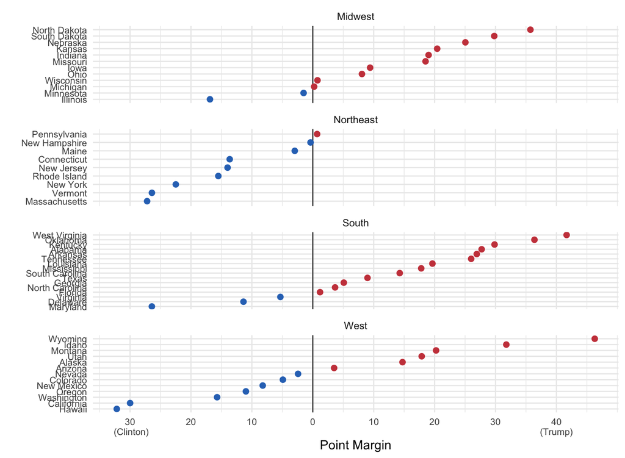

## Map U.S. state-level data

- Let us get a data frame of the US state map

```r
us_states <- map_data("state")
head(us_states)
```

```
##        long      lat group order  region subregion
## 1 -87.46201 30.38968     1     1 alabama      <NA>
## 2 -87.48493 30.37249     1     2 alabama      <NA>
## 3 -87.52503 30.37249     1     3 alabama      <NA>
## 4 -87.53076 30.33239     1     4 alabama      <NA>
## 5 -87.57087 30.32665     1     5 alabama      <NA>
## 6 -87.58806 30.32665     1     6 alabama      <NA>
```

```r
dim(us_states)
```

```
## [1] 15537     6
```

## Map U.S. state-level data

```r
p <- ggplot(data = us_states,
            mapping = aes(x = long, y = lat,
                          group = group))

p + geom_polygon(fill = "white", color = "black")
```

- A map is a set of lines drawn in the right order on a grid.

## Map U.S. state-level data

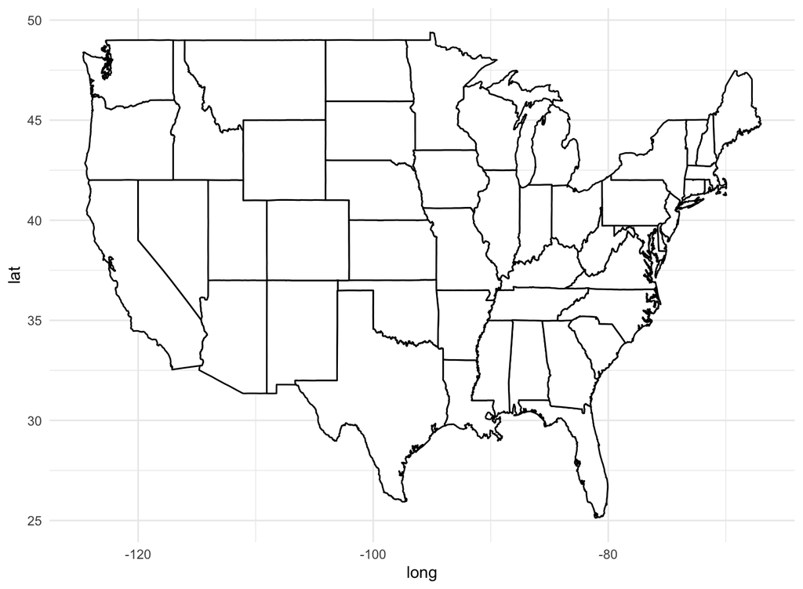

## Map U.S. state-level data

- Let’s `fill` the map.

```r
p <- ggplot(data = us_states,
            aes(x = long, y = lat,
                group = group, fill = region))

p + geom_polygon(color = "gray90", size = 0.1) + guides(fill = FALSE)
```

## Map U.S. state-level data

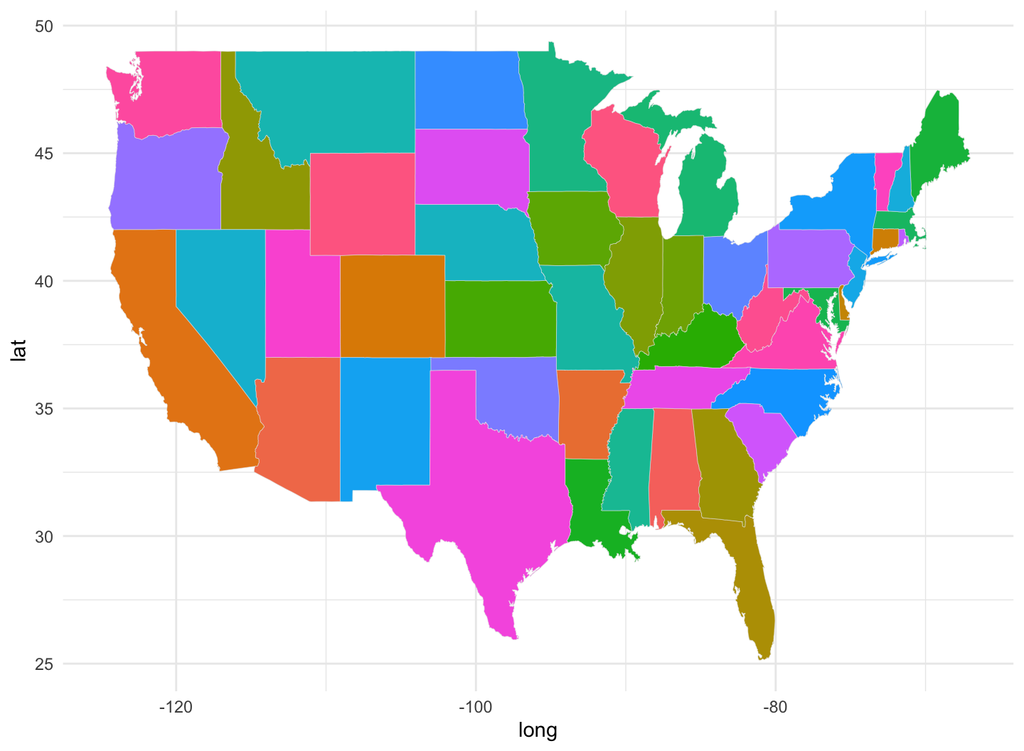

## Map U.S. state-level data

- Let’s deal with the projection.
  - By default, the map is plotted using the venerable *Mercator* projection.
  - The *Albers* projection is nicer.

```r
p <- ggplot(data = us_states,
            mapping = aes(x = long, y = lat,
                          group = group, fill = region))

p + geom_polygon(color = "gray90", size = 0.1) +
    coord_map(projection = "albers", lat0 = 39, lat1 = 45) +
    guides(fill = FALSE)
```

- We can transform the default projection used by `geom_polygon()`, via the `coord_map()` function.
  - The *Albers* projection requires two latitude parameters, `lat0` and `lat1`.

## Map U.S. state-level data

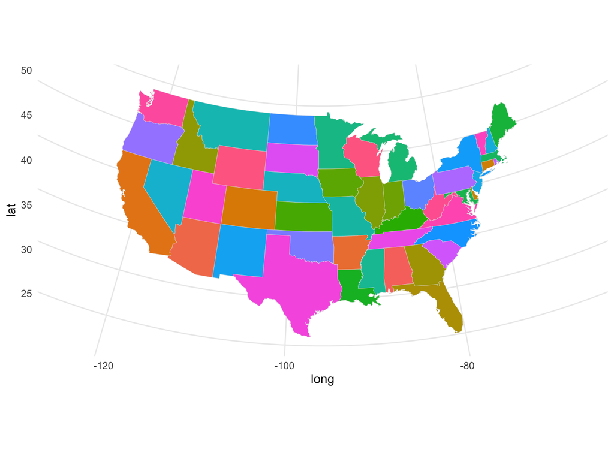

## Map U.S. state-level data

- Let’s get the `election` data on to the map

```r
election$region <- tolower(election$state)
us_states_elec <- left_join(us_states, election)
```

- In the map data, `us_states`, the state names (in a variable named `region`) are in lower case.
- Here we can create a variable in the `election` data frame to correspond to this, using the `tolower()` function to convert the state names.
- It is important to know your data and variables well enough to check that they have merged properly.
  - FIPS code is useful in joining the data.

## Map U.S. state-level data

```r
p0 <- ggplot(data = us_states_elec,
            aes(x = long, y = lat,
                group = group, fill = party))

p0 + geom_polygon(color = "gray90", size = 0.1) +
    coord_map(projection = "albers", lat0 = 39, lat1 = 45)
```

## Map U.S. state-level data

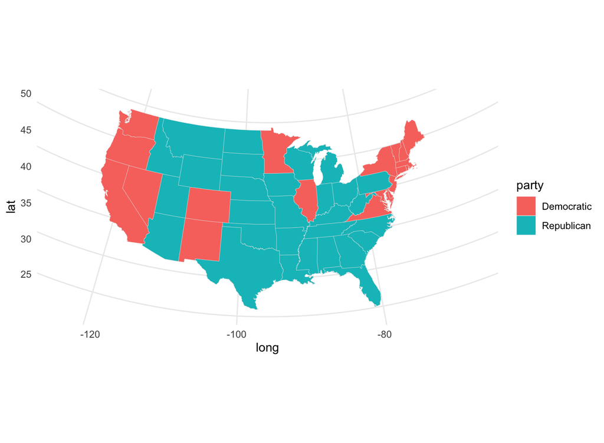

## Map U.S. state-level data

```r
p1 <- p0 + geom_polygon(color = "gray90", size = 0.1) +
    coord_map(projection = "albers", lat0 = 39, lat1 = 45)

p2 <- p1 + scale_fill_manual(values = party_colors) +
    labs(title = "Election Results 2016", fill = NULL)

p2 + theme_map()
```

## Map U.S. state-level data

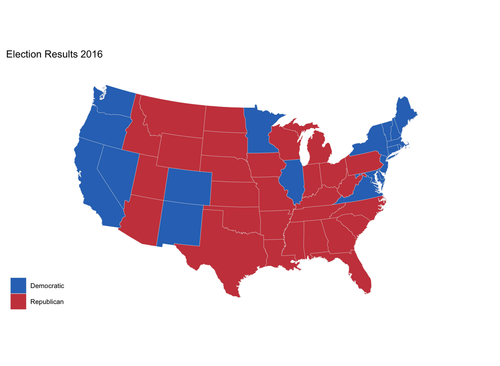

## Map U.S. state-level data

- To the `fill` aethetic, let’s try a continuous measure, such as the percentage of the vote received by Donald Trump (`pct_trump`).

```r
p0 <- ggplot(data = us_states_elec,
             mapping = aes(x = long, y = lat, group = group, fill = pct_trump))

p1 <- p0 + geom_polygon(color = "gray90", size = 0.1) +
    coord_map(projection = "albers", lat0 = 39, lat1 = 45)

p1 + labs(title = "Trump vote") + theme_map() + labs(fill = "Percent")
```

## Map U.S. state-level data

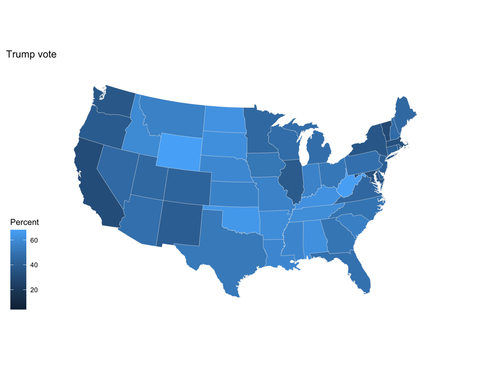

## Map U.S. state-level data

- Blue is not the color we want here.
- The color gradient runs in the wrong direction.
- Let’s fix these problems using `scale_fill_gradient()`:

```r
p2 <- p1 + scale_fill_gradient(low = "white", high = "#CB454A") +
        labs(title = "Trump vote")
p2 + theme_map() + labs(fill = "Percent")
```

## Map U.S. state-level data

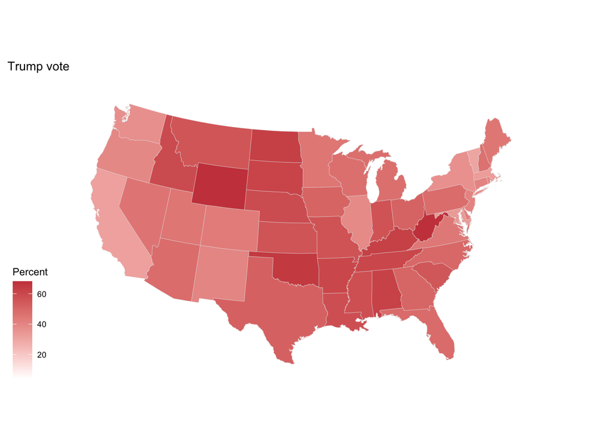

## Map U.S. state-level data

- For election results, we might prefer a gradient that diverges from a midpoint.
  - The `scale_gradient2()` function gives us a blue-red spectrum that passes through white by default.
  - We can also re-specify the mid-level color along with the `high` and `low` colors.

```r
p0 <- ggplot(data = us_states_elec,
             mapping = aes(x = long, y = lat, group = group, fill = d_points))

p1 <- p0 + geom_polygon(color = "gray90", size = 0.1) +
    coord_map(projection = "albers", lat0 = 39, lat1 = 45)

p2 <- p1 + scale_fill_gradient2() + labs(title = "Winning margins")
p2 + theme_map() + labs(fill = "Percent")
```

## Map U.S. state-level data

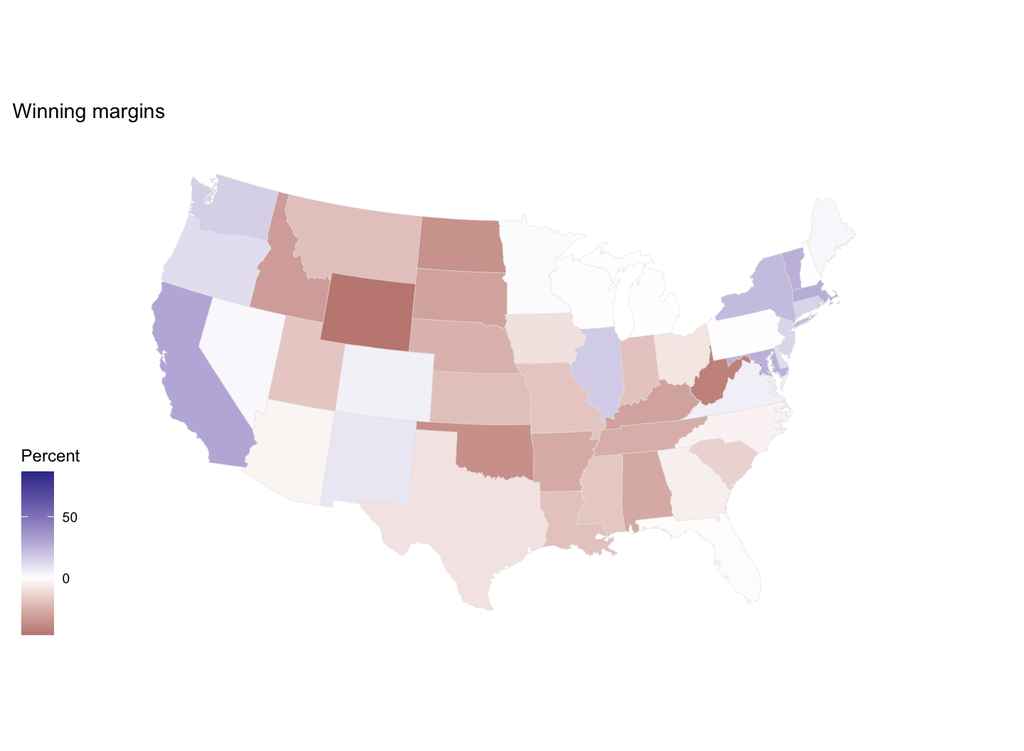

## Map U.S. state-level data

- From the `scale_gradient2()` function, we can also re-specify the mid-level color along with the `high` and `low` colors.

```r
p3 <- p1 + scale_fill_gradient2(low = "red",
                                mid = scales::muted("purple"),
                                high = "blue",
                                breaks = c(-25, 0, 25, 50, 75))
p3 + theme_map() + labs(fill = "Percent", title = "Winning margins")
```

## Map U.S. state-level data

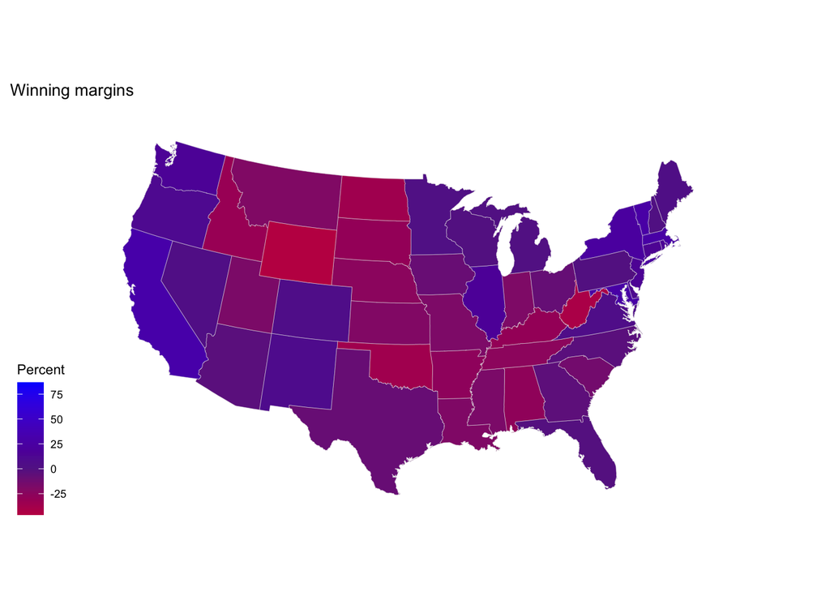

## Map U.S. state-level data

```r
p0 <- ggplot(data = subset(us_states_elec,
                           region %nin% "district of columbia"),
             aes(x = long, y = lat, group = group, fill = d_points))

p3 <- p1 + scale_fill_gradient2(low = "red",
                                mid = scales::muted("purple"),
                                high = "blue",
                                breaks = c(-25, 0, 25, 50, 75))
p3 + theme_map() + labs(fill = "Percent", title = "Winning margins", caption = "DC is omitted.")
```

## Map U.S. state-level data

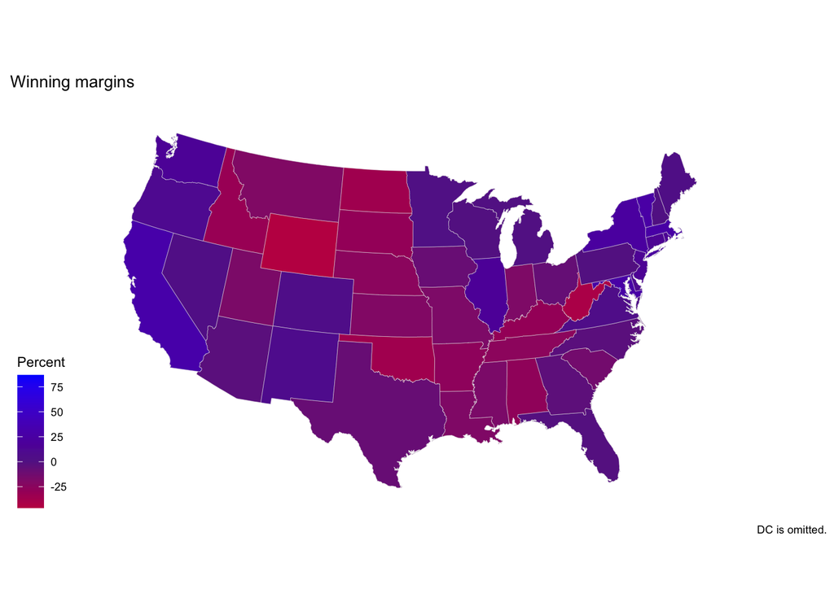